# Python w zastosowaniach naukowych

## Wykład 8

### mgr inż. Maciej Kwiatkowski

## IPython

[Ipython](https://ipython.org/) to rozbudowany projekt wspierający interaktywne obliczenia. W ramach projektu tworzone są:

- *interaktywna konsola* (REPL - *Read Evaluate Print Loop*) o wiele bardziej rozbudowana niż wbudowana konsola Pythona,
- *kernel* Pythona - usługa interpretera,
- *debugger*,
- narzędzia do *zrównoleglania* obliczeń,
- *GUI* wykorzystujące przeglądarkę internetową (obecnie jest to już oddzielny projekt, niezależny od języka Python) - **Jupyter**

Ipython jest dostępny jako paczka instalowalna przez pip: `pip install ipython`

Główne cechy interaktywnej konsoli:

- przechowywanie historii wejść (również między sesjami),
- przechowywanie historii wyjść (w ramach sesji),
- kolorowanie składni,
- lepsza interakcja z blokiem kodu (możliwość wczytania bloku kodu z historii),
- komendy magiczne: `%` (dla linii) i `%%` (blok kodu) pozwalające m.in. na komunikację z os, zarządzanie plikami etc.,

```python
print?
```

### Profilowanie z użyciem metod magicznych IPythona

Profilowanie to rodzaj dynamicznej (z udziałem użytkownika) analizy kodu pod względem m.in. złożoności czasowej i pamięciowej.

Przykład sprawdzenia kodu pod wględem czasu wykonania:

```python
%timeit sum(range(int(1e6)))
```

```
19.2 ms ± 1.31 ms per loop (mean ± std. dev. of 7 runs, 10 loops each)
```

```python
%%timeit
_sum = 0
for ii in range(int(1e6)):
    _sum += ii
```

```
52.1 ms ± 1.31 ms per loop (mean ± std. dev. of 7 runs, 10 loops each)
```

## Jupyter

[Jupyter notebook](https://jupyter-notebook.readthedocs.io/en/stable/) to graficzny interfejs użytkownika (*GUI*) rozwijany w ramach projektu [Jupyter](https://jupyter.org). Interfejs ten jest aplikacją uruchamianą w przeglądarce rozszerzająca funkcjonalność interaktywnej konsoli Ipython jednocześnie pozwalając na przechowywanie sesji w formie pliku z rozszerzeniem `.ipynb`.

Podobnie jak Ipython jest dostępny jako paczka instalowalna przez pip: `pip install jupyter`.

Proces jupytera uruchamia się za pomocą komendy `jupyter notebook`.

Komenda uruchamia *serwer* notebooka, który dostępny jest w sieci lokalnej. W domyślnej instalacji uruchomienie serwera uruchamia domyślną przeglądarkę / dodaje kartę z interfejsem.

[figure not shown]

[Żródło](https://jupyter.readthedocs.io/en/latest/_images/notebook_components.png)

W interfejsie notebooka istotne są dwa widoki:

- `tree` będącego głównie eksploratorem plików (root folderem jest folder uruchomienia serwera), oraz
- `notebooks` pozwalającym na edycję notebooków.

*Kernel* to proces, który wykonuje obliczenia zdefiniowane w notebooku. Do jednego kernela można odwołać się z kilku notebooków.

Przykładem takiego kernela jest IPython, ale dostępne są również kernele dla języka R, Julia (oficijalnie wspierane) oraz inne, napisane przez community.

Sam Jupyter jest dość rozbudowanym projektem z bardziej rozbudowanym intefejsem zakrawającym o IDE ([Jupyter Labs](https://jupyterlab.readthedocs.io/en/latest/)), usługą pozwalającą na serwowanie współdzielonych notebooków ([Jupyter Hub](https://jupyterhub.readthedocs.io/en/stable/)). Są także miejsze paczki pozwalające np. na eksportowanie notebooka do innych formatów ([`nbconverter`](https://nbconvert.readthedocs.io/en/latest/)) czy zamiany w interaktywną prezentację [`rise`](https://rise.readthedocs.io/en/maint-5.6/))

W ramach zajęć będziemy korzystać z podstawowej (out of the box) wersji notebooka.

### Zalety:

- Pozwala na szybkie prototypowanie kodu,
- Pozwala na szybką analizę danych / tworzenie kodu do obliczeń (przechowywanie wyniku każdej lini),
- Ułatwia prezentowanie wyników, robienie prezentacji ad hoc.

### Wady

- Dzielenie kodu między notebookami jest problematyczne:
  - możemy albo podłączyć kilka konsol do jednego kernela i w efekcie mieć dostęp do przestrzeni nazw, ale jest ona wspólna dla wszystkich,
  - musimy ręcznie wydzielać kod do zależności,
- Format notebooka jest nieczytelny dla nieprogramistów, więc trzeba dodać trochę *boilerplate* kodu przed prezentacją,
- Wersjonowanie wymaga pewnych tricków, ale i tak może stwarzać problemy, gdy nad plikiem ma pracować więcej osób.
- Długie sesje / duże *outputy* mogą spowolnić / uniemożliwić pracę (ale można to obejść ustawiając historię i cache na 0).

## Matplotlib

### Uruchomienie

Matplotlib jest "inspirowaną" MATLABem paczką do tworzenia wykresów i animacji.

Instalacja przez pip: `pip install matplotlib`.

**UWAGA**: Matplotlib wymaga numpy!

### Importowanie

W paczce występują dwa moduły `pyplot` i `pylab`. `pyplot` jest modułem zawierającym funkcje odpowiedzialne za tworzenie wykresów. `pylab` zawiera przestrzeń nazw zbliżoną do MATLABA (zarówno funkcje odpowiedzialne za wykreślanie jak i obliczenia w numpy).

Zalecam używanie `pyplot`: `import matplotlib.pyplot as plt`

### Przykład użycia

```python
import matplotlib.pyplot as plt
import numpy as np
```

```python
x = np.linspace(0, 5, 10)
y = x ** 2
```

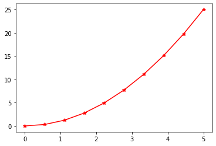

```python
# Jupyter domyślnie rysuje wykres wewnątrz dokumentu.
# %matplotlib inline
# Ale można zmienić to na rysowanie do oddzielnego okna, np.:
# %matplotlib tk
# Możliwe jest zamiana backendu na pozwalający na interakcję z rysunkiem
# UWAGAPrzy zmianie backendu konieczne jest zrestartowanie kernela!
# %matplotlib notebook
plt.plot(x,y, 'r-*')  # nie mamy dostępu do tego wykresu
```

### Składowe wykresu

[figure not shown]

[Żródło](https://matplotlib.org/_images/anatomy1.png)

### Figure i axes

Podstawowym obiektem w module jest `figure` (rycina(?) albo obrazek), który w swojej przestrzeni może zawierać wiele `axes` (układów współrzędnych/wykresów). To rozróżnienie jest istotne, dlatego proszę zapamiętać, że:

- `axes` związane jest ze sposobem prezentowania danych (na poprzednim rysunku większość zaznaczonych obiektów było atrybutami wykresu),
- `figure` związany jest z ogólnymi parametrami rysunku jako grafiki, która może być zapisana.

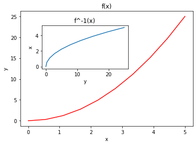

```python
fig = plt.figure()  # obrazek zawierający wszystkie wykresy

ax_1 = fig.add_axes([0.1, 0.1, 0.8, 0.8]) # głowny wykres
ax_2 = fig.add_axes([0.2, 0.5, 0.4, 0.3]) # wykres zagnieżdżony

# main figure
ax_1.plot(x, y, 'r')
ax_1.set_xlabel('x')
ax_1.set_ylabel('y')
ax_1.set_title('f(x)')

# insert
ax_2.plot(y, x)
ax_2.set_xlabel('y')
ax_2.set_ylabel('x')
ax_2.set_title('f^-1(x)');
```

```python
# mając referencję do obiektu możemy go edytować
ax_2.set_position([0.3, 0.5, 0.4, 0.3])
```

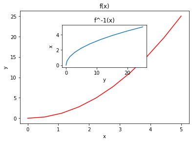

```python
fig
```

### Wiele wykresów

```python
# Pomocnicza funkcja
def plot_multiple(axes, x, ys):
    for ii, (ax, y) in enumerate(zip(axes, ys), 1):
        ax.plot(x, y, 'r')
        ax.set_xlabel('x')
        ax.set_ylabel('y')
        ax.set_title(f'title {ii}')
```

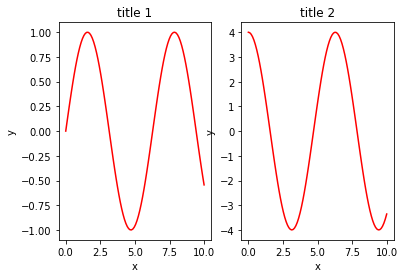

```python
x = np.linspace(0, 10, 100)
ys = np.vstack([np.sin(x), 4*np.cos(x)])
# metoda domyślnie tworzy wiele wykresów w ramach jednego obrazka
fig, axes = plt.subplots(nrows=1, ncols=2)
plot_multiple(axes, x, ys)
```

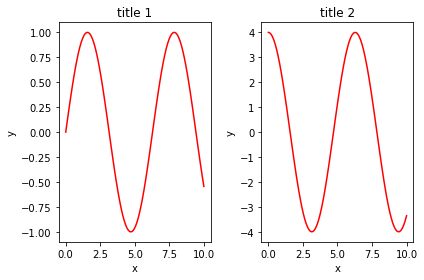

```python
# Automatyczne dopasowywanie zawartości, żeby uniknąć nachodzenia na siebie
fig.tight_layout()
fig
```

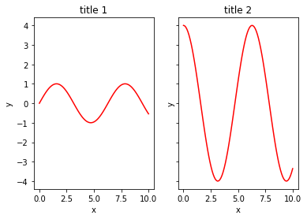

```python
# W celu zwiększenia czytelności można uwspólnić oś
fig, axes = plt.subplots(nrows=1, ncols=2, sharey=True)
plot_multiple(axes, x, ys)
```

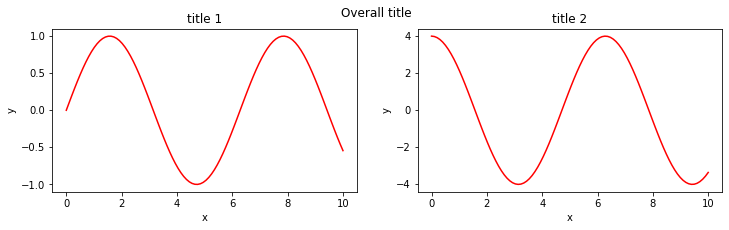

```python
# W celu lepszego dopasowania obrazka do zawrtości
# można zmodyfikować proporcję obrazka przez parametr figsize
# przyjmujący tuplę (szerokość, wysokość)
fig, axes = plt.subplots(nrows=1, ncols=2, figsize=(12, 3))
plot_multiple(axes, x, ys)
fig.suptitle('Overall title')
```

### Legenda

Legenda jest atrybutem wykresu. Można ją dodać do wykresu na dwa sposoby:

- inicjując etykiety przy rysowaniu (sugerowana metoda, ponieważ łączy etykietę z krzywą),
- etykietując każdą krzywą przy wstawianiu legendy.

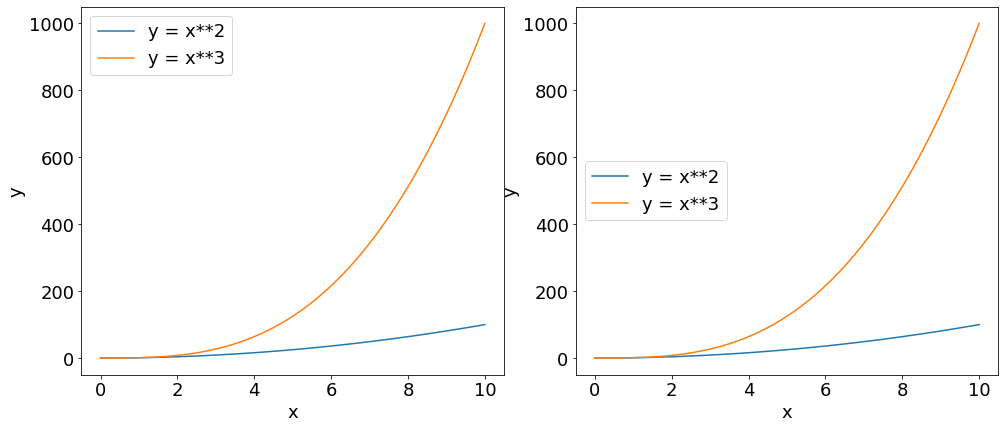

```python
import matplotlib as mpl
mpl.rcParams['font.size']=18
fig, axes = plt.subplots(ncols=2, figsize=(14, 6))

# etykietowanie przy rysowaniu
ax_1 = axes[0]
ax_1.plot(x, x**2, label="y = x**2")
ax_1.plot(x, x**3, label="y = x**3")
ax_1.legend(loc=2)  # parametr określa położenie legendy

# etykietowanie przy wstawianiu legendy
ax_2 = axes[1]
ax_2.plot(x, x**2)
ax_2.plot(x, x**3)
ax_2.legend(["y = x**2", "y = x**3"], loc=6)

fig.tight_layout()
for ax in axes:
    ax.set_xlabel('x')
    ax.set_ylabel('y')
```

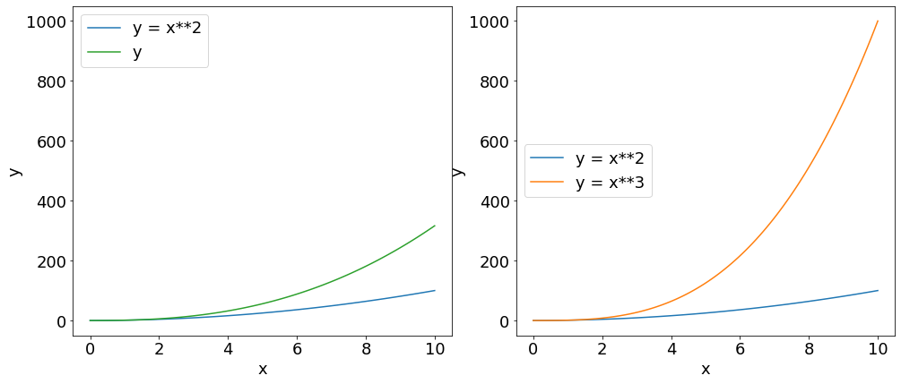

```python
ax_1.lines.pop()
ax_1.plot(x, x**2.5, label="y")
ax_1.legend(loc=2)  # parametr określa położenie legendy
fig
```

Obecne etykiety nie są jeszcze w 100% akceptowalne, gdyż zawierają składnie kodu. W celu poprawienia ich czytelności można użyć skadni LaTeXa. Inne formatowanie (zmiana kroju/rozmiaru czionki) opisane jest [tutaj](https://matplotlib.org/3.1.1/tutorials/introductory/customizing.html).

**UWAGA**: Zalecam używania raw stringów, żeby nie trzeba było escapować '\' używangeo w znakach specjalnych LaTeXa.

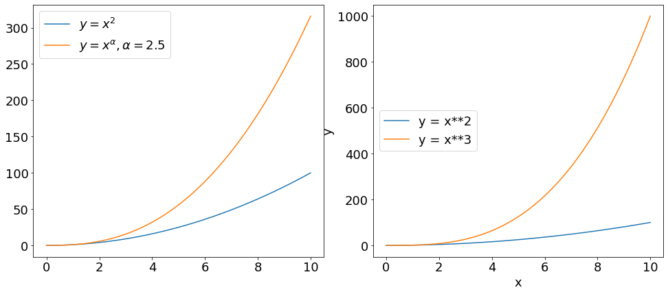

```python
ax_1.clear()
ax_1.plot(x, x**2, label=r"$y = x^2$")
ax_1.plot(x, x**2.5, label=r"$y = x^\alpha, \alpha=2.5$")
ax_1.legend(loc=2)
fig
```

```python
mpl.rcdefaults()  # przywraca domyślne stylowanie
```

### Bliźniacze osie

W niektórych przypadkach przydatne będzie naniesienie dwóch osi na jeden wykres.Można to zrealziować za pomocą metody `twinx` lub `twiny`.

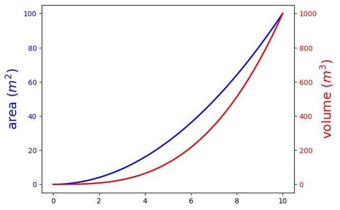

```python
fig, ax1 = plt.subplots()

ax1.plot(x, x**2, lw=2, color="blue")
ax1.set_ylabel(r"area $(m^2)$", fontsize=18, color="blue")
for label in ax1.get_yticklabels():
    label.set_color("blue")

ax2 = ax1.twinx()
ax2.plot(x, x**3, lw=2, color="red")
ax2.set_ylabel(r"volume $(m^3)$", fontsize=18, color="red")
for label in ax2.get_yticklabels():
    label.set_color("red")
```

Osie nie muszą być w tej samej skali.

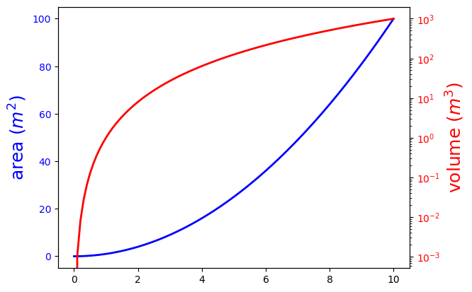

```python
fig, ax1 = plt.subplots()

ax1.plot(x, x**2, lw=2, color="blue")
ax1.set_ylabel(r"area $(m^2)$", fontsize=18, color="blue")
for label in ax1.get_yticklabels():
    label.set_color("blue")

ax2 = ax1.twinx()
ax2.semilogy(x, x**3, lw=2, color="red")
ax2.set_ylabel(r"volume $(m^3)$", fontsize=18, color="red")
for label in ax2.get_yticklabels():
    label.set_color("red")
```

### Inne typy wykresów

```python
n = np.array([0,1,2,3,4,5])
xx = np.linspace(-0.75, 1., 100)
```

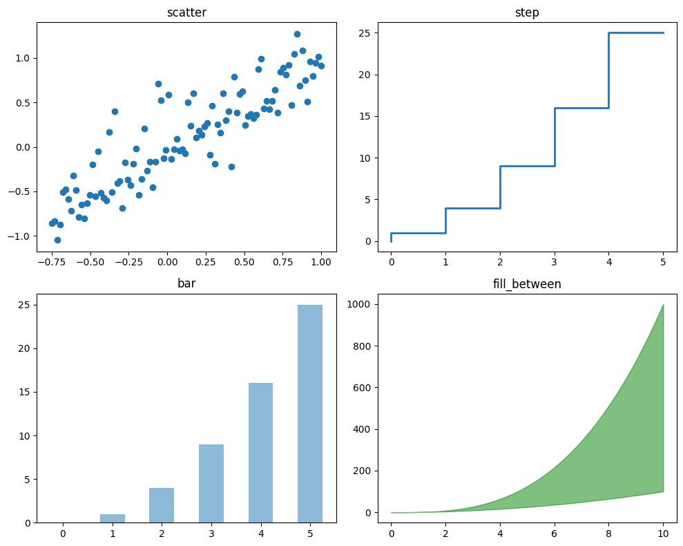

```python
fig, axes = plt.subplots(2,2, figsize=(10,8))

axes[0, 0].scatter(xx, xx + 0.25*np.random.randn(len(xx)))
axes[0, 0].set_title("scatter")

axes[0, 1].step(n, n**2, lw=2)
axes[0, 1].set_title("step")

axes[1, 0].bar(n, n**2, align="center", width=0.5, alpha=0.5)
axes[1, 0].set_title("bar")

axes[1, 1].fill_between(x, x**2, x**3, color="green", alpha=0.5);
axes[1, 1].set_title("fill_between");

fig.tight_layout()
```

#### Histogramy

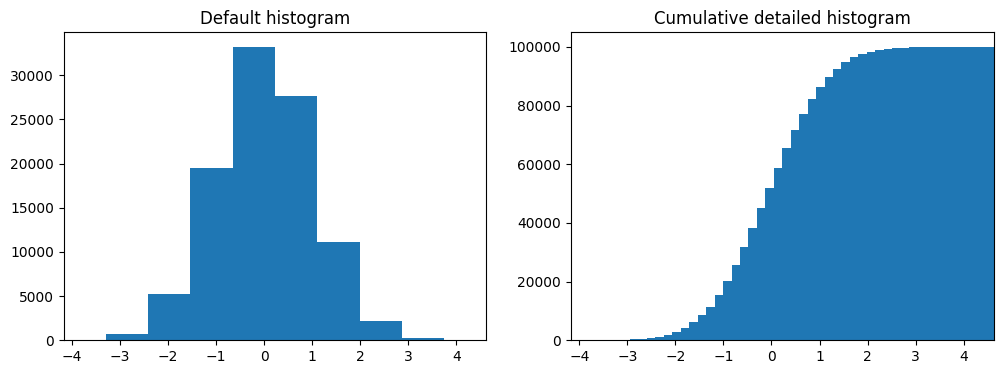

```python
n = np.random.randn(100000)
fig, axes = plt.subplots(1, 2, figsize=(12,4))

axes[0].hist(n)
axes[0].set_title("Default histogram")
axes[0].set_xlim((min(n), max(n)))

axes[1].hist(n, cumulative=True, bins=50)
axes[1].set_title("Cumulative detailed histogram")
axes[1].set_xlim((min(n), max(n)));
```

#### Wykres we współrzędnych polarncyh

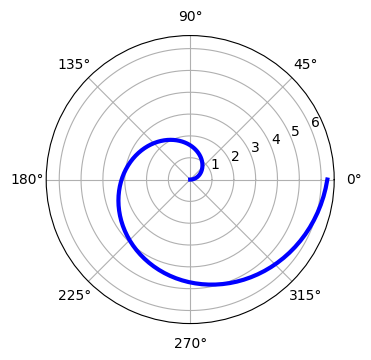

```python
fig = plt.figure()
# parametr polar zmienia typ wykresu
ax = fig.add_axes([0.0, 0.0, .6, .6], polar=True)
t = np.linspace(0, 2 * np.pi, 100)
ax.plot(t, t, color='blue', lw=3);
```

#### Wykres z niepewnościami

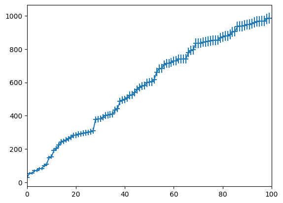

```python
x = np.arange(0, 100)
data = np.random.randint(10, 1000, (100))
data.sort()
stddev = np.sqrt(data)
xerr = np.ones_like(x)
plt.errorbar(x, data, xerr=xerr, yerr=stddev)
plt.xlim(0, 100);
```

#### Prezntowanie macierzy

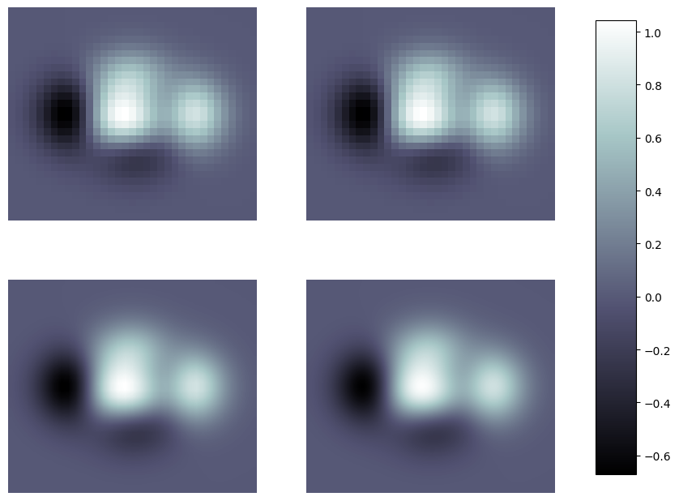

```python
def f(x,y):
    return (1-x/2+x**5+y**3)*np.exp(-x**2-y**2)

n = 10
x = np.linspace(-3,3,3.5*n)
y = np.linspace(-3,3,3.0*n)
X,Y = np.meshgrid(x,y)
Z = f(X,Y)

fig, axes = plt.subplots(2, 2, figsize=(10, 8))
for ax, interp in zip(
    axes.flatten(),
    [None, 'nearest', 'bilinear', 'bicubic']
):
    im = ax.imshow(
        Z,
    #     interpolation=None,
        interpolation=interp,
        cmap='bone',
        origin='lower',
    )
    ax.axis('off')


fig.subplots_adjust(right=0.8)
cbar_ax = fig.add_axes([0.85, 0.15, 0.05, 0.7])
fig.colorbar(im, cax=cbar_ax, shrink=.92);
```

### Zapis obrazka

Jak już wspomniałem zapis jest metodą obrazka :). Przed zapisaniem obrazka polecam sprawdzić, czy wszystkie wykresy układają się poprawnie.

Ważnymi atrybutami:

- dpi (*dot per inch*) - im większy tym większy obrazek, ale przy złożonych wykresach zapewnia czytelność (nie będą "rozpikselowane"),
- format (rozpoznawany po rozszerzeniu) - osobiście polecam png (nie kompresowalny).

```python
fig.savefig('img1.png', dpi=100)
fig.savefig('img2.png', dpi=200)
```

```python
%system ls -lh img*
```

```
['-rw-r--r-- 1 tutor tutor  71K gru  5 23:43 img1.png',
 '-rw-r--r-- 1 tutor tutor 171K gru  5 23:43 img2.png']
```

## Przydatne linki

- [A gallery of interesting Jupyter Notebooks](https://github.com/jupyter/jupyter/wiki/A-gallery-of-interesting-Jupyter-Notebooks#general-topics-in-scientific-computing)
- [Kurs Matplotlib, inspiracja dla części wykładu](https://nbviewer.jupyter.org/github/jrjohansson/scientific-python-lectures/blob/master/Lecture-4-Matplotlib.ipynb#)
- [Inny kurs, trochę bardziej przekrojowy](https://github.com/rougier/matplotlib-tutorial)